# SoccerFouls

Do fouls matter in women’s college soccer? In this assignment, you’ll be working with a dataset that contains information about soccer matches from last season. You’ll load the data, perform some basic statistical analysis, and create a visualization to explore the relationship between fouls and the goal differential (and thus the outcome). Follow the steps below to complete the assignment.

### Task 1: Load the tidyverse

```r
library(tidyverse)
```

### Task 2: Load the soccer dataset from https://raw.githubusercontent.com/dwillis/NCAAWomensSoccerData/refs/heads/main/data/ncaa_womens_soccer_matchstats_2024.csv

```r
matches <- read_csv("https://raw.githubusercontent.com/dwillis/NCAAWomensSoccerData/refs/heads/main/data/ncaa_womens_soccer_matchstats_2024.csv")
```

### Task 3: Create a new column called `goal_diff` that calculates the difference between the two teams’ goals.

```r
matches <- matches |> mutate(goal_diff = team_score - opponent_score)
```

### Task 4: Use `summarize()` and the `cor()` function to calculate the correlation between fouls and goal differential, using the pearson method.

```r
matches |> summarize(correlation = cor(fouls, goal_diff, method="pearson"))
```

```
## # A tibble: 1 × 1
##   correlation
##         <dbl>
## 1      0.0181
```

### Task 5: Create a scatterplot of fouls and goal differential, using `geom_point()`

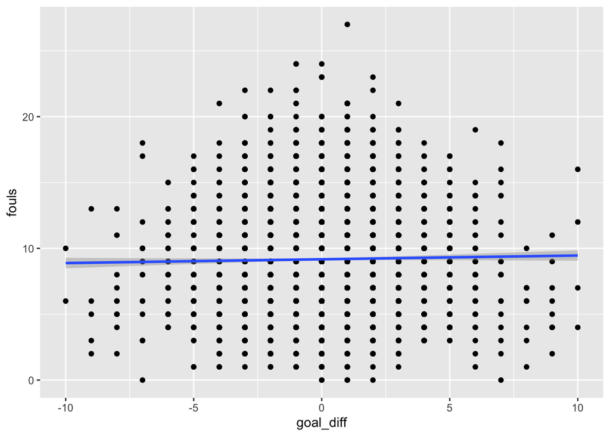

```r
matches |>
  ggplot() +
  geom_point(aes(x=goal_diff, y=fouls)) +
  geom_smooth(aes(x=goal_diff, y=fouls), method="lm")
```

### Task 6: Describe the results of both the correlation calculation and the scatterplot.

The correlation coefficient is 0.018 which is very close to 0. This means that there is no linear relationship between the number of fouls and how much a team loses and wins. The scatterplot looks like a meaningless blob with spread out results with the average forming a straight line through the middle- this siggests no linear correlation

### Task 7: Choose another variable and repeat the steps in Tasks 4-5, then describe the results.

```r
matches |> summarize(correlation = cor(corners, goal_diff, method="pearson"))
```

```
## # A tibble: 1 × 1
##   correlation
##         <dbl>
## 1       0.379
```

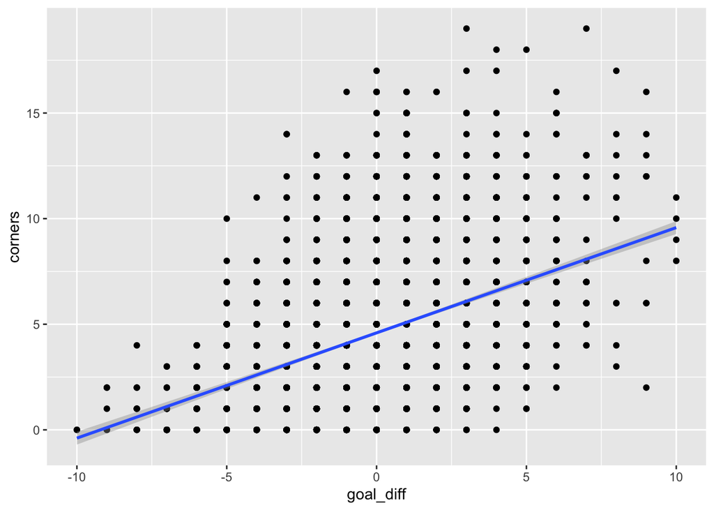

```r
matches |>
  ggplot() +
  geom_point(aes(x=goal_diff, y=corners)) +
  geom_smooth(aes(x=goal_diff, y=corners), method="lm")
```

The results of the corners and goal difference is a moderately positive relationship to one another. The correlation is 0.379 that indicates a positive relationship- although not a strong one. In the scatterplot there is a clear steady upward trend meaning as goal diff increases so do the amount of corners. Although corners are meaningfully associated with goal difference but a higher number of corners aren’t exactly consequential to scoring more goals and winning matches.

When you are done, save your work, switch to GitHub Desktop, then add, commit and push your changes to GitHub and submit the URL of the notebook in ELMS.